# Supervised Learning - Foundations Project: ReCell

## Problem Statement

### Business Context

Buying and selling used phones and tablets used to be something that happened on a handful of online marketplace sites. But the used and refurbished device market has grown considerably over the past decade, and a new IDC (International Data Corporation) forecast predicts that the used phone market would be worth \$52.7bn by 2023 with a compound annual growth rate (CAGR) of 13.6% from 2018 to 2023. This growth can be attributed to an uptick in demand for used phones and tablets that offer considerable savings compared with new models.

Refurbished and used devices continue to provide cost-effective alternatives to both consumers and businesses that are looking to save money when purchasing one. There are plenty of other benefits associated with the used device market. Used and refurbished devices can be sold with warranties and can also be insured with proof of purchase. Third-party vendors/platforms, such as Verizon, Amazon, etc., provide attractive offers to customers for refurbished devices. Maximizing the longevity of devices through second-hand trade also reduces their environmental impact and helps in recycling and reducing waste. The impact of the COVID-19 outbreak may further boost this segment as consumers cut back on discretionary spending and buy phones and tablets only for immediate needs.

### Objective

The rising potential of this comparatively under-the-radar market fuels the need for an ML-based solution to develop a dynamic pricing strategy for used and refurbished devices. ReCell, a startup aiming to tap the potential in this market, has hired you as a data scientist. They want you to analyze the data provided and build a linear regression model to predict the price of a used phone/tablet and identify factors that significantly influence it.

### Data Description

The data contains the different attributes of used/refurbished phones and tablets. The data was collected in the year 2021. The detailed data dictionary is given below.

- brand_name: Name of manufacturing brand
- os: OS on which the device runs
- screen_size: Size of the screen in cm
- 4g: Whether 4G is available or not
- 5g: Whether 5G is available or not
- main_camera_mp: Resolution of the rear camera in megapixels
- selfie_camera_mp: Resolution of the front camera in megapixels
- int_memory: Amount of internal memory (ROM) in GB
- ram: Amount of RAM in GB
- battery: Energy capacity of the device battery in mAh
- weight: Weight of the device in grams
- release_year: Year when the device model was released
- days_used: Number of days the used/refurbished device has been used
- normalized_new_price: Normalized price of a new device of the same model in euros
- normalized_used_price: Normalized price of the used/refurbished device in euros

## Importing necessary libraries

```python
# Installing the libraries with the specified version.
# uncomment and run the following line if Google Colab is being used
# !pip install scikit-learn==1.2.2 seaborn==0.13.1 matplotlib==3.7.1 numpy==1.25.2 pandas==1.5.3 -q --user
```

```python
# Installing the libraries with the specified version.
# uncomment and run the following lines if Jupyter Notebook is being used
# !pip install scikit-learn==1.2.2 seaborn==0.11.1 matplotlib==3.3.4 numpy==1.24.3 pandas==1.5.2 -q --user
```

**Note**: *After running the above cell, kindly restart the notebook kernel and run all cells sequentially from the start again.*

```python
# To make sure code is structured better and readable automatically
%load_ext nb_black

# Importing libraries for data manipulation
import numpy as np
import pandas as pd

# Importing libraries for data visualization
import matplotlib.pyplot as plt
import seaborn as sns

sns.set()

# Splitting the dataset into train and test datasets
from sklearn.model_selection import train_test_split

# To build linear regression models using statsmodels
import statsmodels.api as sm

# To check model performance
from sklearn.metrics import r2_score, mean_absolute_error, mean_squared_error

# To compute VIF
from statsmodels.stats.outliers_influence import variance_inflation_factor
```

```python
import warnings
warnings.filterwarnings('ignore')
```

## Loading the dataset

```python
df = pd.read_csv('C:/Users/mardin/Downloads/DATASETS - MACHINE LEARNING/used_device_data.csv')
```

## Data Overview

- Observations
- Sanity checks

#### Observations

```python
# Displaying the first five rows of the dataset
df.head()
```

|  | brand_name | os | screen_size | 4g | 5g | main_camera_mp | selfie_camera_mp | int_memory | ram | battery | weight | release_year | days_used | normalized_used_price | normalized_new_price |
| --- | --- | --- | --- | --- | --- | --- | --- | --- | --- | --- | --- | --- | --- | --- | --- |
| 0 | Honor | Android | 14.50 | yes | no | 13.0 | 5.0 | 64.0 | 3.0 | 3020.0 | 146.0 | 2020 | 127 | 4.307572 | 4.715100 |
| 1 | Honor | Android | 17.30 | yes | yes | 13.0 | 16.0 | 128.0 | 8.0 | 4300.0 | 213.0 | 2020 | 325 | 5.162097 | 5.519018 |
| 2 | Honor | Android | 16.69 | yes | yes | 13.0 | 8.0 | 128.0 | 8.0 | 4200.0 | 213.0 | 2020 | 162 | 5.111084 | 5.884631 |
| 3 | Honor | Android | 25.50 | yes | yes | 13.0 | 8.0 | 64.0 | 6.0 | 7250.0 | 480.0 | 2020 | 345 | 5.135387 | 5.630961 |
| 4 | Honor | Android | 15.32 | yes | no | 13.0 | 8.0 | 64.0 | 3.0 | 5000.0 | 185.0 | 2020 | 293 | 4.389995 | 4.947837 |

```python
# Checking the shape of the dataset
df.shape
```

```
(3454, 15)
```

```python
# Checking the data types of the columns
df.info()
```

```
<class 'pandas.core.frame.DataFrame'>
RangeIndex: 3454 entries, 0 to 3453
Data columns (total 15 columns):
 #   Column                 Non-Null Count  Dtype
---  ------                 --------------  -----
 0   brand_name             3454 non-null   object
 1   os                     3454 non-null   object
 2   screen_size            3454 non-null   float64
 3   4g                     3454 non-null   object
 4   5g                     3454 non-null   object
 5   main_camera_mp         3275 non-null   float64
 6   selfie_camera_mp       3452 non-null   float64
 7   int_memory             3450 non-null   float64
 8   ram                    3450 non-null   float64
 9   battery                3448 non-null   float64
 10  weight                 3447 non-null   float64
 11  release_year           3454 non-null   int64
 12  days_used              3454 non-null   int64
 13  normalized_used_price  3454 non-null   float64
 14  normalized_new_price   3454 non-null   float64
dtypes: float64(9), int64(2), object(4)
memory usage: 404.9+ KB
```

```python
# Checking the summary statistics of the data
df.describe(include="all").T
```

|  | count | unique | top | freq | mean | std | min | 25% | 50% | 75% | max |
| --- | --- | --- | --- | --- | --- | --- | --- | --- | --- | --- | --- |
| brand_name | 3454 | 34 | Others | 502 | NaN | NaN | NaN | NaN | NaN | NaN | NaN |
| os | 3454 | 4 | Android | 3214 | NaN | NaN | NaN | NaN | NaN | NaN | NaN |
| screen_size | 3454.0 | NaN | NaN | NaN | 13.713115 | 3.80528 | 5.08 | 12.7 | 12.83 | 15.34 | 30.71 |
| 4g | 3454 | 2 | yes | 2335 | NaN | NaN | NaN | NaN | NaN | NaN | NaN |
| 5g | 3454 | 2 | no | 3302 | NaN | NaN | NaN | NaN | NaN | NaN | NaN |
| main_camera_mp | 3275.0 | NaN | NaN | NaN | 9.460208 | 4.815461 | 0.08 | 5.0 | 8.0 | 13.0 | 48.0 |
| selfie_camera_mp | 3452.0 | NaN | NaN | NaN | 6.554229 | 6.970372 | 0.0 | 2.0 | 5.0 | 8.0 | 32.0 |
| int_memory | 3450.0 | NaN | NaN | NaN | 54.573099 | 84.972371 | 0.01 | 16.0 | 32.0 | 64.0 | 1024.0 |
| ram | 3450.0 | NaN | NaN | NaN | 4.036122 | 1.365105 | 0.02 | 4.0 | 4.0 | 4.0 | 12.0 |
| battery | 3448.0 | NaN | NaN | NaN | 3133.402697 | 1299.682844 | 500.0 | 2100.0 | 3000.0 | 4000.0 | 9720.0 |
| weight | 3447.0 | NaN | NaN | NaN | 182.751871 | 88.413228 | 69.0 | 142.0 | 160.0 | 185.0 | 855.0 |
| release_year | 3454.0 | NaN | NaN | NaN | 2015.965258 | 2.298455 | 2013.0 | 2014.0 | 2015.5 | 2018.0 | 2020.0 |
| days_used | 3454.0 | NaN | NaN | NaN | 674.869716 | 248.580166 | 91.0 | 533.5 | 690.5 | 868.75 | 1094.0 |
| normalized_used_price | 3454.0 | NaN | NaN | NaN | 4.364712 | 0.588914 | 1.536867 | 4.033931 | 4.405133 | 4.7557 | 6.619433 |
| normalized_new_price | 3454.0 | NaN | NaN | NaN | 5.233107 | 0.683637 | 2.901422 | 4.790342 | 5.245892 | 5.673718 | 7.847841 |

- Android is the most common Operating System.
- About 2335 devices have 4G capability and about 3302 devices do *NOT* have 5G capability.
- The average normalized_used_price of a device is 4.36 Euros.

#### Sanity Checks

```python
# Checking for duplicate values
df.duplicated().sum()
```

```
0
```

There are zero duplicates in this dataset

```python
# Checking for missing values
df.isnull().sum()
```

```
brand_name                 0
os                         0
screen_size                0
4g                         0
5g                         0
main_camera_mp           179
selfie_camera_mp           2
int_memory                 4
ram                        4
battery                    6
weight                     7
release_year               0
days_used                  0
normalized_used_price      0
normalized_new_price       0
dtype: int64
```

There are 179 missing values in the column **`main_camera_mp`**. Moreover there are 2 missing values in the column **`selfie_camera_mp`**, 4 missing values in both **`int_memory`** and **`ram`** columns, 6 missing values in **`battery`**, and 7 missing values in the column **`weight`**.

```python
# Creating a copy of the dataset so that the original stays unchanged
df2 = df.copy()
```

## Exploratory Data Analysis (EDA)

- EDA is an important part of any project involving data.
- It is important to investigate and understand the data better before building a model with it.
- A few questions have been mentioned below which will help you approach the analysis in the right manner and generate insights from the data.
- A thorough analysis of the data, in addition to the questions mentioned below, should be done.

**Questions**:

1. What does the distribution of normalized used device prices look like?
2. What percentage of the used device market is dominated by Android devices?
3. The amount of RAM is important for the smooth functioning of a device. How does the amount of RAM vary with the brand?
4. A large battery often increases a device's weight, making it feel uncomfortable in the hands. How does the weight vary for phones and tablets offering large batteries (more than 4500 mAh)?
5. Bigger screens are desirable for entertainment purposes as they offer a better viewing experience. How many phones and tablets are available across different brands with a screen size larger than 6 inches?
6. A lot of devices nowadays offer great selfie cameras, allowing us to capture our favorite moments with loved ones. What is the distribution of devices offering greater than 8MP selfie cameras across brands?
7. Which attributes are highly correlated with the normalized price of a used device?

### Univariate Analysis

#### Numerical variables

```python
# Defining functions to plot and visualize numerical variables to avoid congestion and repetitiveness

def boxplot_and_histogram(df, column, size = (14, 8), kde = False, bins = None):

    # Plots a boxplot on top and histogram below for a specific column.

    # Set up the figure and two plots (boxplot and histogram)
    fig, (ax1, ax2) = plt.subplots(2, 1, figsize = size, sharex = True,
                                   gridspec_kw = {'height_ratios': [1, 3]})

    # Boxplot (top)
    sns.boxplot(x = df[column], ax = ax1, color = 'skyblue', showmeans = True)

    # Histogram (bottom)
    if bins:
        sns.histplot(data = df, x = column, ax = ax2, kde = kde, bins = bins)
    else:
        sns.histplot(data = df, x = column, ax = ax2, kde = kde)

    # Add mean and median lines
    mean_val = df[column].mean()
    median_val = df[column].median()
    ax2.axvline(mean_val, color = 'green', linestyle = '--')
    ax2.axvline(median_val, color = 'red', linestyle = '-')

    # Setting the title, label and layout
    ax1.set(title = f'{column} - Boxplot and Histogram')
    ax2.set(xlabel = column)
    plt.tight_layout()
    plt.show();
```

##### 1. What does the distribution of normalized used device prices look like? **`normalized_used_price`**

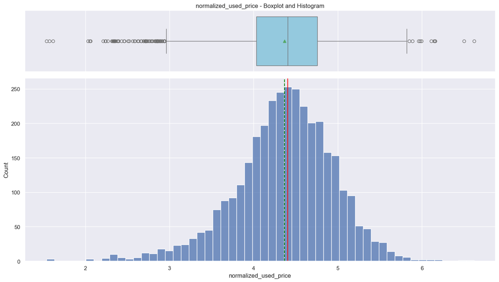

```python
boxplot_and_histogram(df2, 'normalized_used_price')
```

The distribution of normalized used device prices looks normal. The histogram shows a bell-shaped curve.

On average, used devices are sold at a normalized price of between 4 and 5 euros.

**`normalized_new_price`**

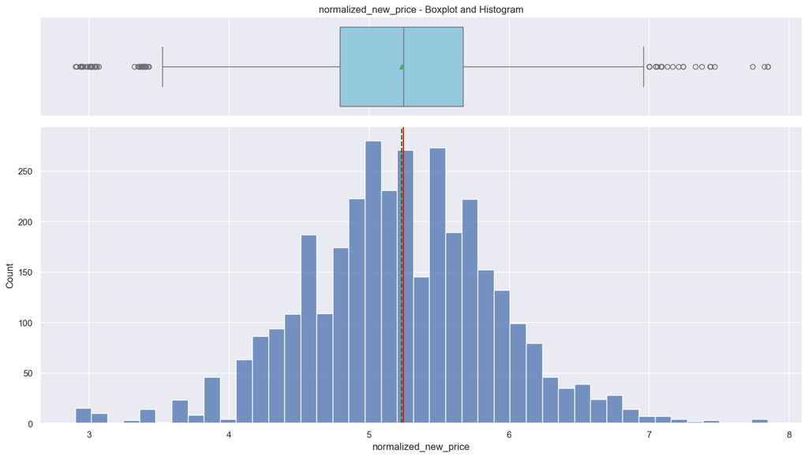

```python
boxplot_and_histogram(df2, 'normalized_new_price')
```

The distribution of normalized new device prices looks close to normal.

On average, new devices are sold at a normalized price of between 5 and 6 euros.

**`days_used`**

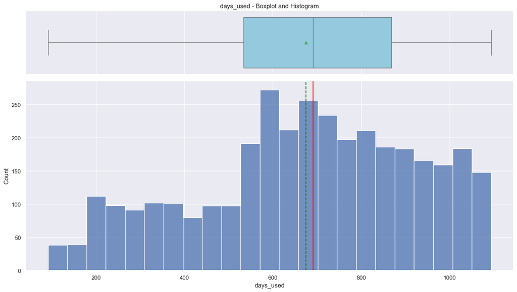

```python
boxplot_and_histogram(df2, 'days_used')
```

The distribution of days looks skewed to the left.

On average, a used device is used for 600 to 800 days.

**`screen_size`**

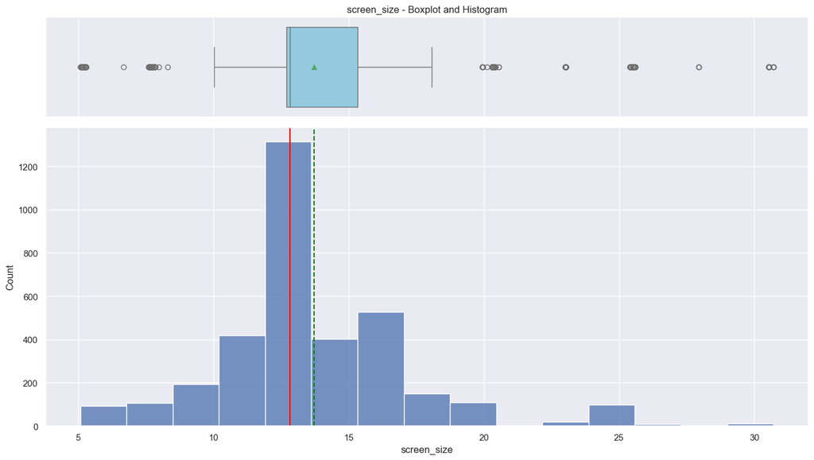

```python
screen_size_bins = [0, 2.5, 5.0, 7.5, 10.0, 12.5, 15.0, 17.5, 20.0, 22.5, 25.0, 27.5, 30.0, 32.5, 35.0]
boxplot_and_histogram(df2, 'screen_size', bins = 15)
```

The distribution of screen size looks close to normal.

On average, the screen size of a device is between 10 and 15 cm.

**`main_camera_mp`**

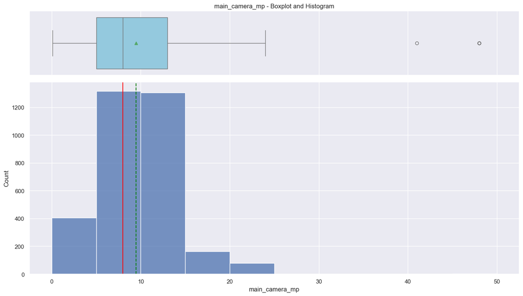

```python
main_camera_bins = [0,5,10,15,20,25,30,35,40,45,50]
boxplot_and_histogram(df2, 'main_camera_mp', bins = main_camera_bins)
```

The distribution of main_camera_mp looks skewed to the right.

On average, the main camera quality of a device is between 7 and 10 Megapixels.

**`selfie_camera_mp`**

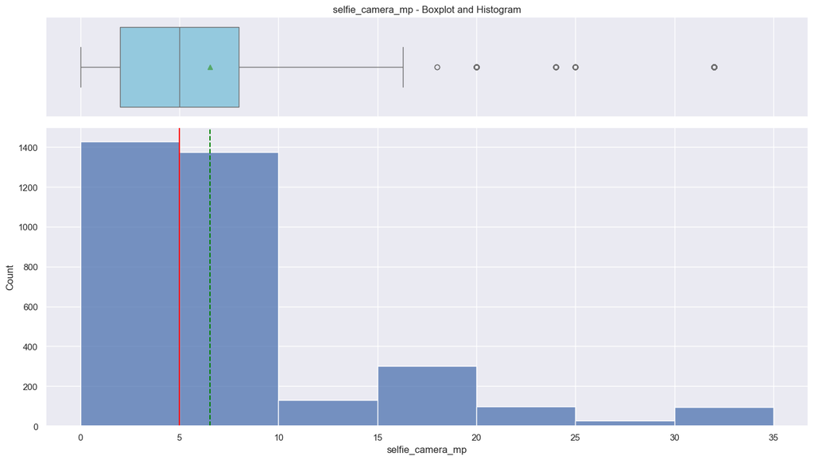

```python
selfie_camera_bins = [0,5,10,15,20,25,30,35]
boxplot_and_histogram(df2, 'selfie_camera_mp', bins = selfie_camera_bins)
```

The distribution of selfie_camera_mp looks skewed to the right.

On average, the selfie camera quality of a device is between 4 and 6 Megapixels.

**`int_memory`**

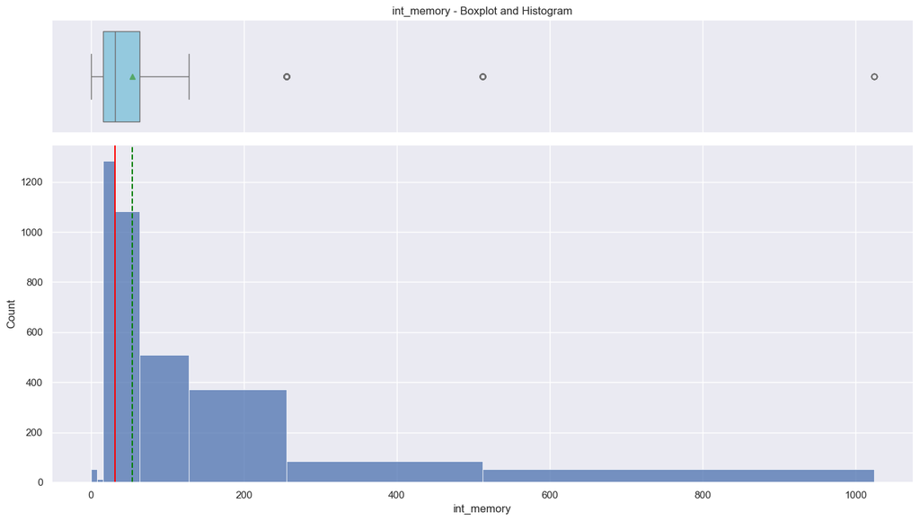

```python
int_memory_bins = [0,8,16,32,64,128,256,512,1024]
boxplot_and_histogram(df2, 'int_memory', bins = int_memory_bins)
```

The distribution of internal storage looks skewed to the right with outlier presence

On average, the internal storage capacity of a device is between 32 and 64 GB.

**`ram`**

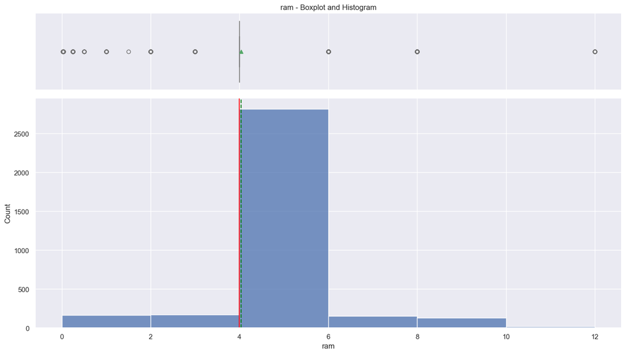

```python
ram_bins = [0, 2, 4, 6, 8, 10, 12]
boxplot_and_histogram(df2, 'ram', bins = ram_bins)
```

There is a heavy presence of outliers in the RAM boxplot.

**`battery`**

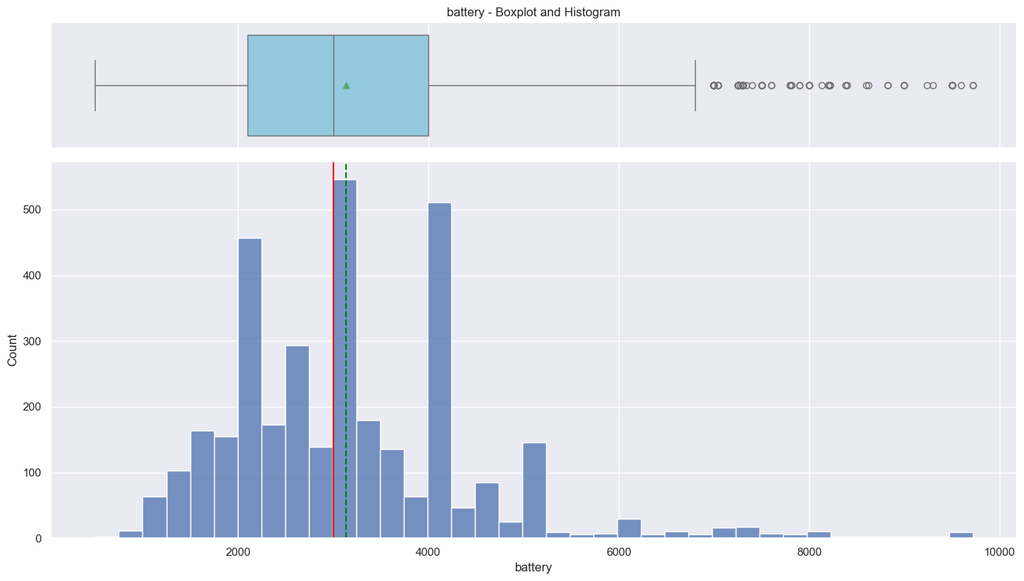

```python
boxplot_and_histogram(df2, 'battery')
```

The distribution of battery size looks skewed to the right with heavy presence of outliers.

On average, the battery size of a device is between 2000 and 4000 mAH.

**`weight`**

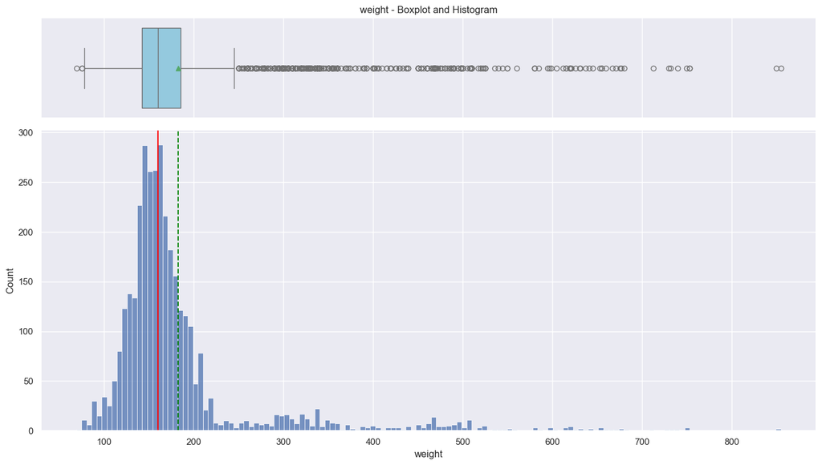

```python
boxplot_and_histogram(df2, 'weight')
```

On average, the weight of a device is between 100 and 200 grams.

#### Categorical Variables

```python
# Defining functions to plot and visualize categorical variables to avoid congestion and repetition

def barplot(df, column, show_perc = False, n = None):

    # Draws a barplot for a column, showing count or percentage labels on top.

    # Total number of rows for percentage calculation
    total_rows = len(df)

    # Ordering of categories by frequency
    value_order = df[column].value_counts().index[:n]

    # Set figure width based on number of bars
    num_bars = len(value_order)
    plt.figure(figsize = (num_bars + 2, 6))

    # Rotate x-axis labels for better visibility
    plt.xticks(rotation = 45, ha = 'right', fontsize = 12)

    # Draw the barplot
    ax = sns.countplot(data = df, x = column, order = value_order, palette = 'Blues')

    # Add labels on top of bars
    for bar in ax.patches:
        height = bar.get_height()
        if show_perc:
            label = f"{(height / total_rows) * 100:.1f}%"
        else:
            label = f"{height}"

        ax.annotate(
            label,
            (bar.get_x() + bar.get_width() / 2, height),
            ha = 'center',
            va = 'bottom',
            fontsize = 11,
            xytext = (0, 5),
            textcoords = 'offset points'
        )

    # Add a title
    ax.set_title(f"{column} Distribution", fontsize = 14)
    plt.tight_layout()
    plt.show();
```

**`brand_name`**

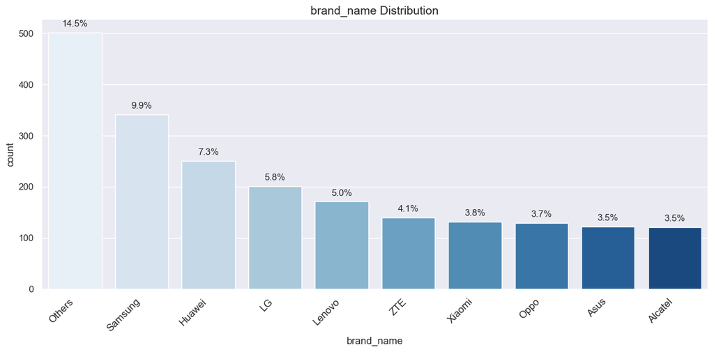

```python
barplot(df2, 'brand_name', show_perc = True, n = 10)
```

##### 2. What percentage of the used device market is dominated by Android devices? **`os`**

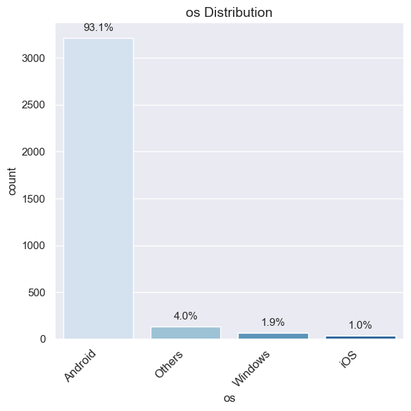

```python
barplot(df2, 'os', show_perc = True)
```

**`4g`**

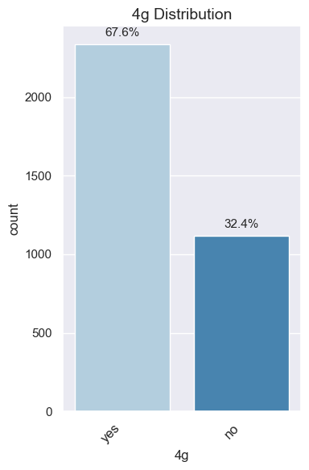

```python
barplot(df2, '4g', show_perc = True)
```

**`5g`**

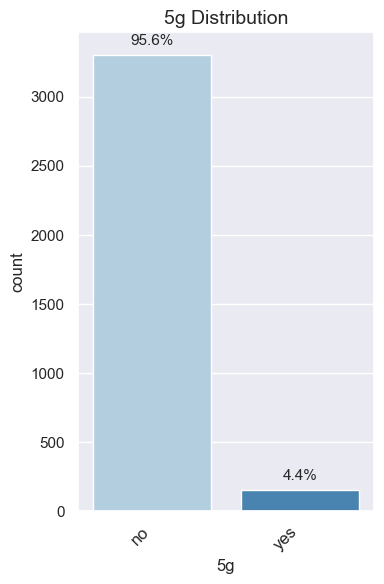

```python
barplot(df2, '5g', show_perc = True)
```

**`release_year`**

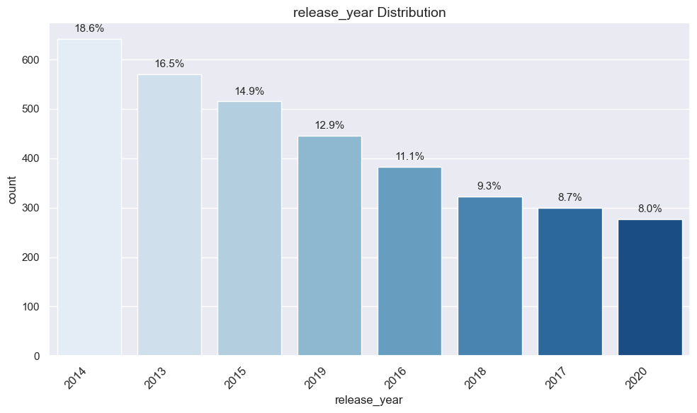

```python
barplot(df2, 'release_year', show_perc = True)
```

### Bivariate / Multivariate Analysis

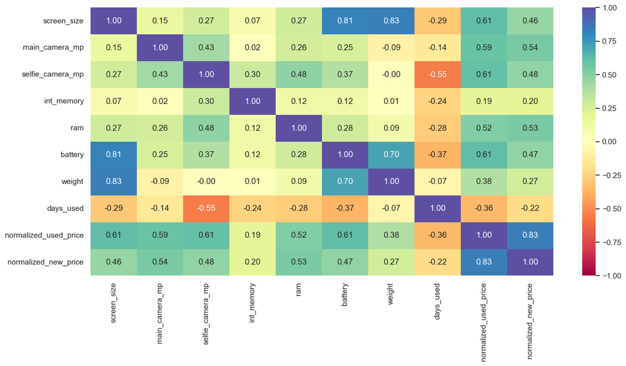

```python
cols_list = df2.select_dtypes(include = np.number).columns.tolist()
cols_list.remove("release_year")

plt.figure(figsize = (15, 7))
sns.heatmap(
    df2[cols_list].corr(), annot = True, vmin = -1, vmax = 1, fmt = ".2f", cmap = "Spectral"
)
plt.show();
```

##### 3. The amount of RAM is important for the smooth functioning of a device. How does the amount of RAM vary with the brand?

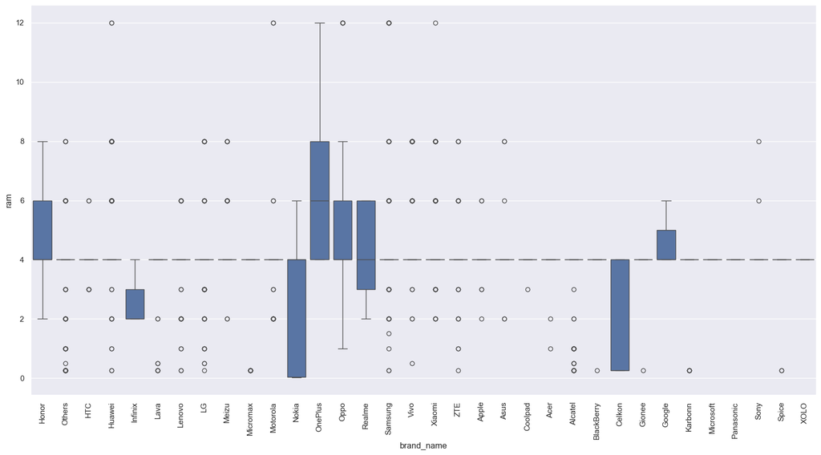

```python
plt.figure(figsize=(20, 10))
sns.boxplot(data = df2, x = 'brand_name', y = 'ram')
plt.xticks(rotation = 90)
plt.show();
```

##### 4. A large battery often increases a device's weight, making it feel uncomfortable in the hands. How does the weight vary for phones and tablets offering large batteries (more than 4500 mAh)?

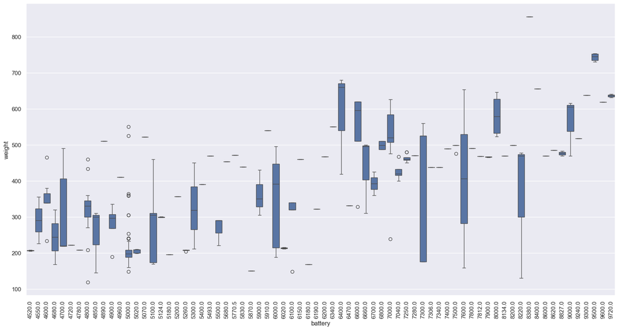

```python
large_battery = df2[df2.battery > 4500]

plt.figure(figsize=(20, 10))
sns.boxplot(data = large_battery, x = 'battery', y = 'weight')
plt.xticks(rotation=90)
plt.show();
```

Higher battery capacity correlates with increased weight.

##### 5. Bigger screens are desirable for entertainment purposes as they offer a better viewing experience. How many phones and tablets are available across different brands with a screen size larger than 6 inches?

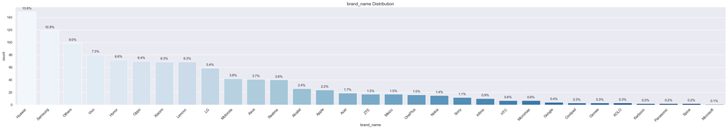

```python
large_screen = df2[df2.screen_size > 6 * 2.54] # To convert inches into cm
barplot(large_screen, 'brand_name', show_perc = True)
```

##### 6. A lot of devices nowadays offer great selfie cameras, allowing us to capture our favorite moments with loved ones. What is the distribution of devices offering greater than 8MP selfie cameras across brands?

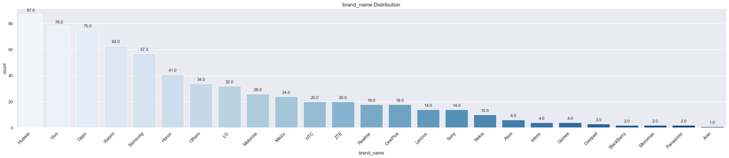

```python
selfie_camera = df2[df2.selfie_camera_mp > 8]
barplot(selfie_camera, 'brand_name')
```

##### 7. Which attributes are highly correlated with the normalized price of a used device?

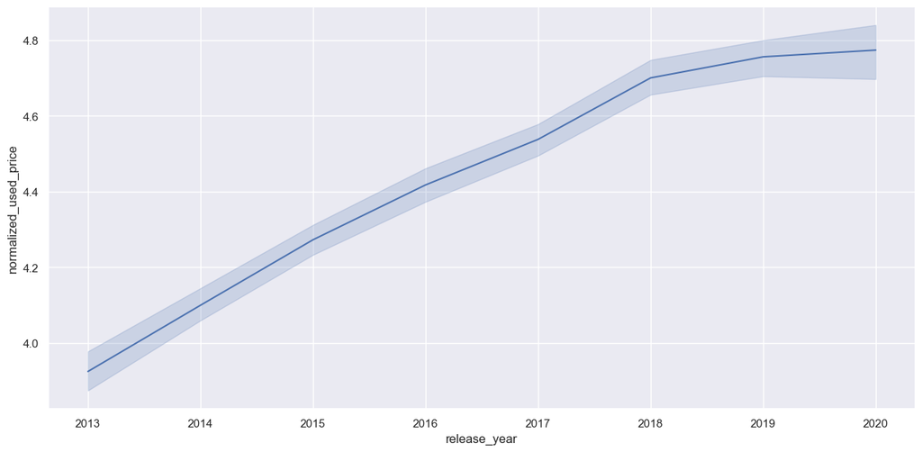

```python
plt.figure(figsize=(15, 7))
sns.lineplot(data = df2, x = 'release_year', y = 'normalized_used_price')
plt.show()
```

There's a clear decline in normalized price as the device gets older **(based on release year)**.

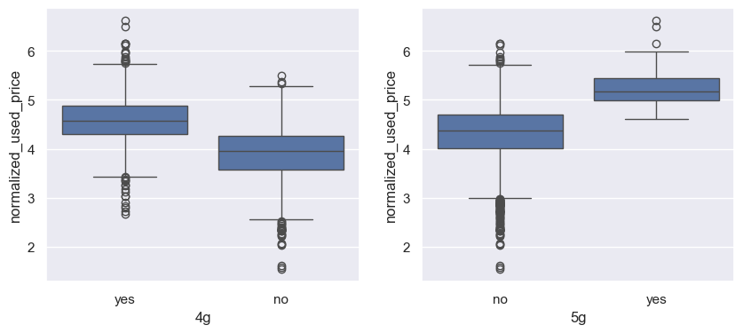

```python
plt.figure(figsize=(10, 4))

plt.subplot(121)
sns.boxplot(data=df2, x="4g", y="normalized_used_price")

plt.subplot(122)
sns.boxplot(data=df2, x="5g", y="normalized_used_price")

plt.show()
```

**5G**-capable phones have higher used prices than those with only **4G**.

## Data Preprocessing

- Missing value treatment
- Feature engineering (if needed)
- Outlier detection and treatment (if needed)
- Preparing data for modeling
- Any other preprocessing steps (if needed)

#### Missing value treatment

We will use the column medians to impute the missing values

```python
df3 = df2.copy()
df3.isnull().sum()
```

```
brand_name                 0
os                         0
screen_size                0
4g                         0
5g                         0
main_camera_mp           179
selfie_camera_mp           2
int_memory                 4
ram                        4
battery                    6
weight                     7
release_year               0
days_used                  0
normalized_used_price      0
normalized_new_price       0
dtype: int64
```

For the columns, we will impute the missing values in each column with the median grouped by `release_year` and `brand_name`.

```python
cols_to_impute = ['main_camera_mp', 'selfie_camera_mp', 'int_memory', 'ram', 'battery', 'weight']

for col in cols_to_impute:
    df3[col] = df3[col].fillna(value = df3.groupby(['release_year','brand_name'])[col].transform('median'))

df3.isnull().sum()
```

```
brand_name                 0
os                         0
screen_size                0
4g                         0
5g                         0
main_camera_mp           179
selfie_camera_mp           2
int_memory                 0
ram                        0
battery                    6
weight                     7
release_year               0
days_used                  0
normalized_used_price      0
normalized_new_price       0
dtype: int64
```

We will impute the remaining missing values in the remaining columns with the median grouped by `brand_name`

```python
cols_to_impute = ['main_camera_mp', 'selfie_camera_mp', 'battery', 'weight']

for col in cols_to_impute:
    df3[col] = df3[col].fillna(value = df3.groupby(['brand_name'])[col].transform('median'))

df3.isnull().sum()
```

```
brand_name                0
os                        0
screen_size               0
4g                        0
5g                        0
main_camera_mp           10
selfie_camera_mp          0
int_memory                0
ram                       0
battery                   0
weight                    0
release_year              0
days_used                 0
normalized_used_price     0
normalized_new_price      0
dtype: int64
```

For the remaining `main_camera_mp` column, we will impute with the median without grouping.

```python
df3["main_camera_mp"] = df3["main_camera_mp"].fillna(df3["main_camera_mp"].median())

df3.isnull().sum()
```

```
brand_name               0
os                       0
screen_size              0
4g                       0
5g                       0
main_camera_mp           0
selfie_camera_mp         0
int_memory               0
ram                      0
battery                  0
weight                   0
release_year             0
days_used                0
normalized_used_price    0
normalized_new_price     0
dtype: int64
```

#### Feature Engineering

```python
df3['years_since_release'] = 2021 - df3['release_year'] # The data was collected in 2021
df3.drop('release_year', axis = 1, inplace = True)

df3['years_since_release'].describe()
```

```
count    3454.000000
mean        5.034742
std         2.298455
min         1.000000
25%         3.000000
50%         5.500000
75%         7.000000
max         8.000000
Name: years_since_release, dtype: float64
```

#### Outlier detection

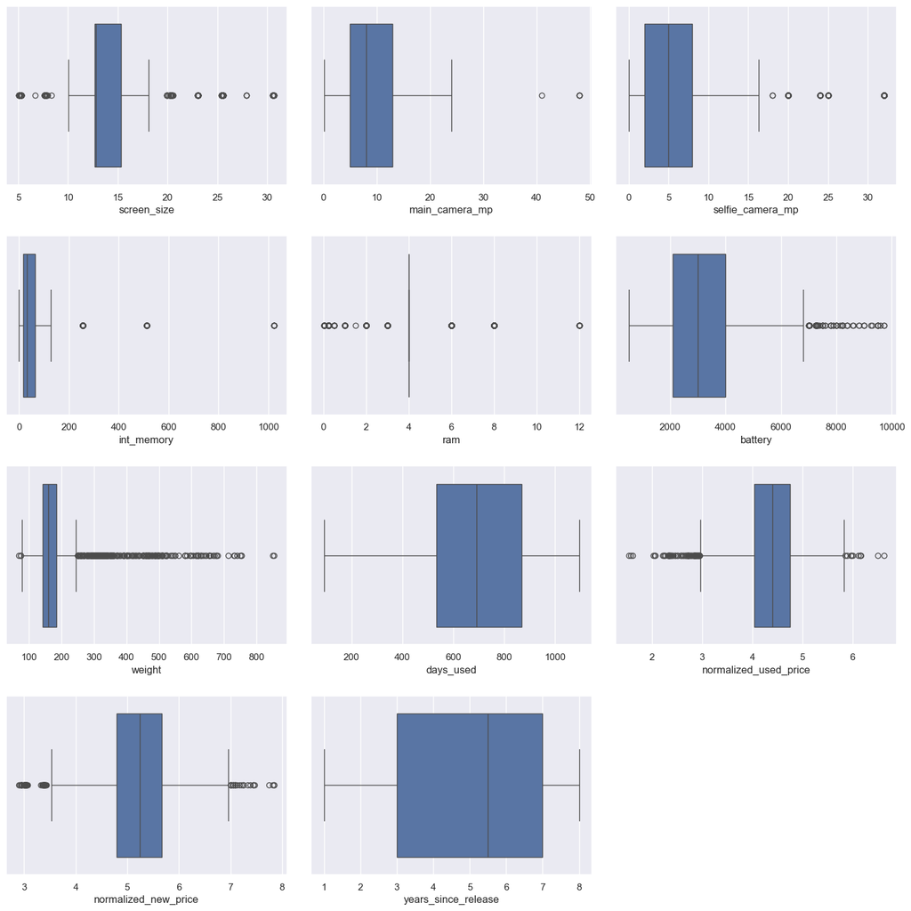

```python
# Outlier detection using boxplot
num_cols = df3.select_dtypes(include = np.number).columns.tolist()

plt.figure(figsize = (15, 15))

for i, variable in enumerate(num_cols):
    plt.subplot(4, 3, i + 1)
    sns.boxplot(data = df3, x = variable)
    plt.tight_layout(pad = 2)

plt.show()
```

There are a number of outliers in the data. However, we will not treat them as they are proper values.

## EDA

- It is a good idea to explore the data once again after manipulating it.

### Univariate Analysis

Performing EDA for the columns that had missing values prior

#### Numerical Variables

**`main_camera_mp`**

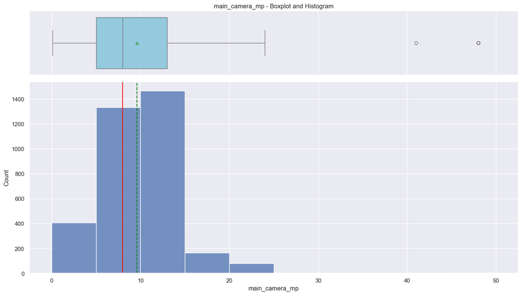

```python
main_camera_bins = [0,5,10,15,20,25,30,35,40,45,50]
boxplot_and_histogram(df3, 'main_camera_mp', bins = main_camera_bins)
```

**`selfie_camera_mp`**

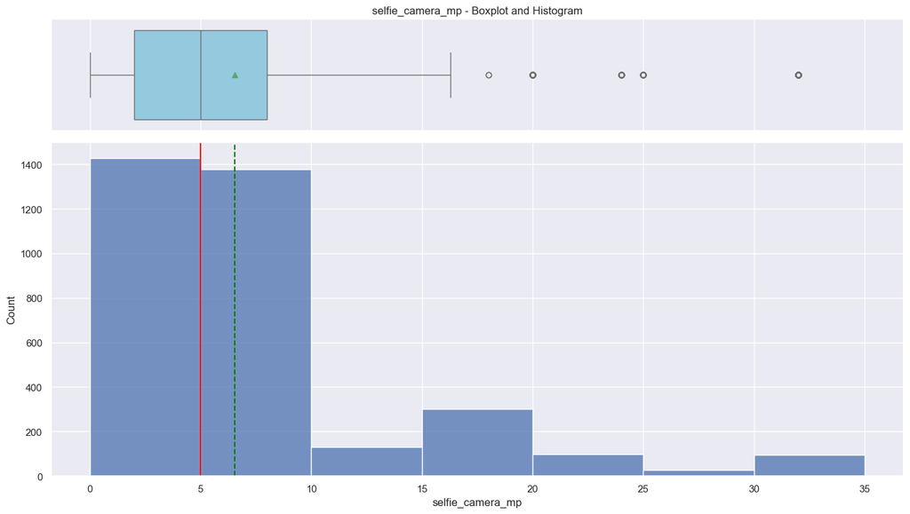

```python
selfie_camera_bins = [0,5,10,15,20,25,30,35]
boxplot_and_histogram(df3, 'selfie_camera_mp', bins = selfie_camera_bins)
```

**`int_memory`**

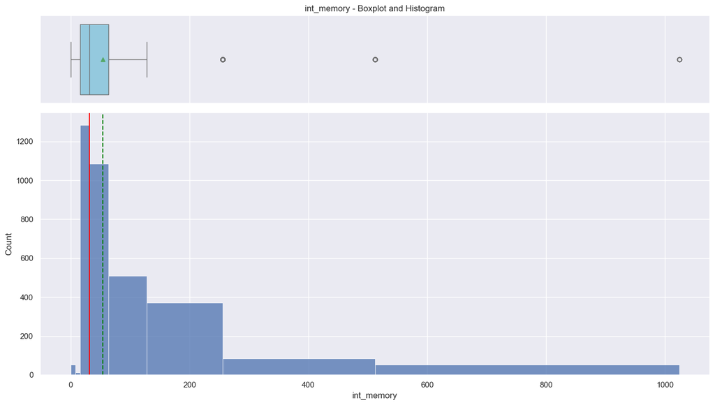

```python
int_memory_bins = [0,8,16,32,64,128,256,512,1024]
boxplot_and_histogram(df3, 'int_memory', bins = int_memory_bins)
```

**`ram`**

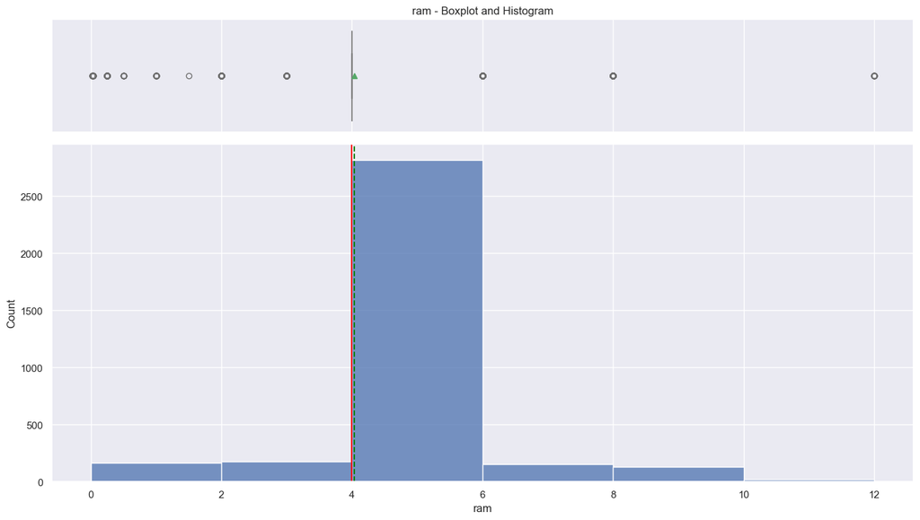

```python
ram_bins = [0, 2, 4, 6, 8, 10, 12]
boxplot_and_histogram(df3, 'ram', bins = ram_bins)
```

**`battery`**

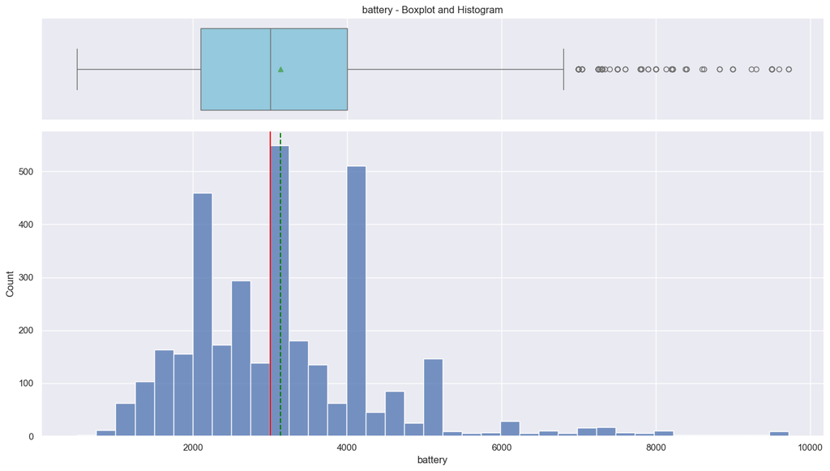

```python
boxplot_and_histogram(df3, 'battery')
```

**`weight`**

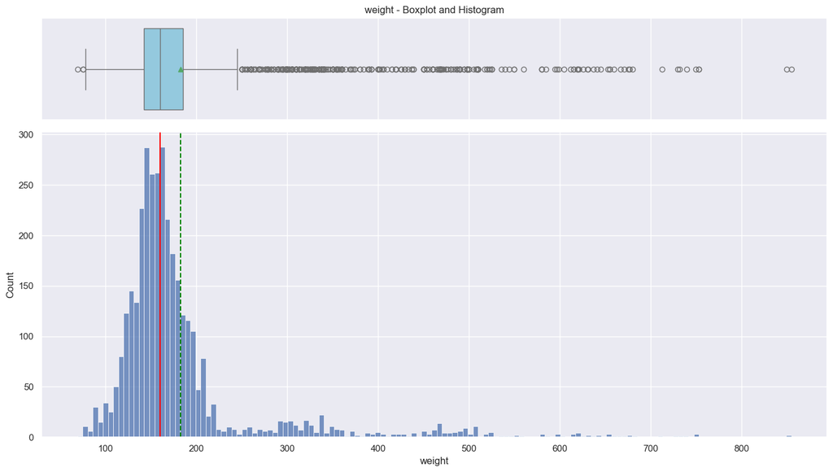

```python
boxplot_and_histogram(df3, 'weight')
```

The distributions of the variables even after treating the missing values still remain fairly the same.

#### Bivariate / Multivariate Analysis

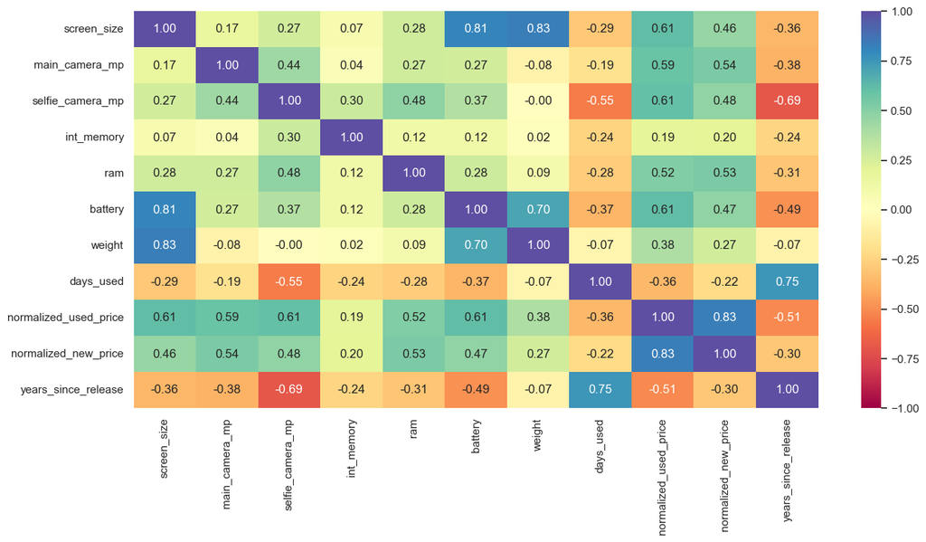

```python
cols_list = df3.select_dtypes(include = np.number).columns.tolist()


plt.figure(figsize = (15, 7))
sns.heatmap(
    df3[cols_list].corr(), annot = True, vmin = -1, vmax = 1, fmt = '.2f', cmap = 'Spectral'
)
plt.show();
```

`normalized_used_price` is **negatively correlated** with `years_since_release`, confirming that **older phones depreciate more**.

##### The amount of RAM is important for the smooth functioning of a device. How does the amount of RAM vary with the brand?

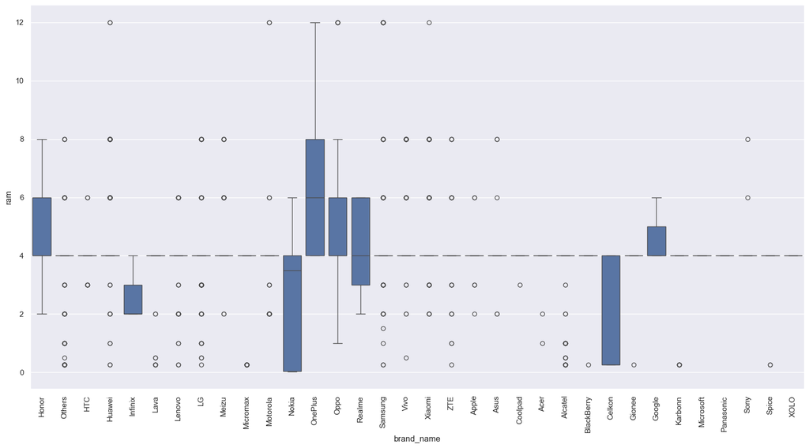

```python
plt.figure(figsize=(20, 10))
sns.boxplot(data = df3, x = 'brand_name', y = 'ram')
plt.xticks(rotation = 90)
plt.show();
```